# **PCFL 2022: Week 6 wrap-up**

Apologies for no recap last week (and the short one this week). The commissioner’s been on research trips around the country and it’s cut into his analysis time.

## Last week’s games

| Winner | Winner’s score | Loser | Loser’s score |
| --- | --- | --- | --- |
| Georgia Peanuts | 101.80 | Captain Clairvoyant | 95.90 |
| Middle Earth Hangry Hobbits | 111.53 | Athens Team Sasquatch | 99.90 |
| KC Gophers | 105.50 | The G.O.A.T. | 78.92 |
| Pigskin on the Gridiron | 107.42 | Southern Sharks | 72.92 |
| Jumpin’ Jaheims | 97.30 | The Juniors | 84.71 |

The byes have begun, and with them, a drop in our scoring. The top matchup last week was the Hobbits vs. the Sasquatch, and Robbie has now dropped two in a row after a hot start. Crissy’s Gophers also stayed hot, roasting Jacob’s GOAT. Evan had a down week points wise, but still managed enough for the W over Erin and Trav. I bested Brian, and Richard got his first W.

## Best performances

### Best players overall

Here’s last week’s **10 best performing starters.**

| Player | Position | NFL Team | Points | PCFL Team |
| --- | --- | --- | --- | --- |
| Joe Burrow | QB | CIN | 32.50 | Captain Clairvoyant |
| Ja’Marr Chase | WR | CIN | 29.70 | Pigskin on the Gridiron |
| Josh Allen | QB | BUF | 26.36 | Athens Team Sasquatch |
| Stefon Diggs | WR | BUF | 25.80 | Georgia Peanuts |
| Brandon Aiyuk | RB/WR/TE | SFO | 24.30 | Southern Sharks |
| Tyreek Hill | WR | MIA | 23.60 | The Juniors |
| Rhamondre Stevenson | RB | NEP | 23.10 | KC Gophers |
| Mike Gesicki | TE | MIA | 21.90 | KC Gophers |
| Mark Andrews | TE | BAL | 20.10 | Middle Earth Hangry Hobbits |
| Michael Pittman Jr. | WR | IND | 19.90 | Captain Clairvoyant |

Check out the tight ends!

### Best players per team

Here’s last week’s top players **on each team.**

| Player | Position | NFL Team | Points | PCFL Team |
| --- | --- | --- | --- | --- |
| Josh Allen | QB | BUF | 26.36 | Athens Team Sasquatch |
| Joe Burrow | QB | CIN | 32.50 | Captain Clairvoyant |
| Stefon Diggs | WR | BUF | 25.80 | Georgia Peanuts |
| Trevor Lawrence | BE | JAC | 24.90 | Jumpin’ Jaheims |
| Rhamondre Stevenson | RB | NEP | 23.10 | KC Gophers |
| Mark Andrews | TE | BAL | 20.10 | Middle Earth Hangry Hobbits |
| Ja’Marr Chase | WR | CIN | 29.70 | Pigskin on the Gridiron |
| Brandon Aiyuk | RB/WR/TE | SFO | 24.30 | Southern Sharks |
| JuJu Smith-Schuster | BE | KCC | 20.80 | The G.O.A.T. |
| Tyreek Hill | WR | MIA | 23.60 | The Juniors |

### Best bench

Who won the **best scoring bench** award last week?

| Team | Bench points |
| --- | --- |
| The G.O.A.T. | 62.12 |
| KC Gophers | 56.30 |
| Georgia Peanuts | 51.28 |
| Athens Team Sasquatch | 48.20 |
| Jumpin’ Jaheims | 41.05 |
| The Juniors | 37.86 |
| Southern Sharks | 35.94 |
| Pigskin on the Gridiron | 29.52 |
| Middle Earth Hangry Hobbits | 27.52 |
| Captain Clairvoyant | 9.90 |

Jacob got the top spot this week, followed by Crissy, me, and Robbie.

Here’s the season’s bench standings:

| Team | Bench points |
| --- | --- |
| Middle Earth Hangry Hobbits | 417.20 |
| The G.O.A.T. | 398.52 |
| KC Gophers | 393.07 |
| Pigskin on the Gridiron | 358.89 |
| Jumpin’ Jaheims | 358.28 |
| Southern Sharks | 341.42 |
| The Juniors | 321.24 |
| Georgia Peanuts | 265.17 |
| Athens Team Sasquatch | 262.22 |
| Captain Clairvoyant | 253.86 |

Scott’s dominant offense extends to his bench as well, while Brian, me, and Robbie are leaving it mostly on the field.

### Best optimized lineups

I compared the actual starting lineups for each team to the hypothetical *best* starting lineup the owner could have started. The table below shows the actual points the team scored, the top score they could have had, and an “optimization” percentage that compares to the two.

| PCFL Team | Actual points | Best lineup | Optimization rate |
| --- | --- | --- | --- |
| Captain Clairvoyant | 95.90 | 100.40 | 96% |
| Pigskin on the Gridiron | 107.42 | 113.72 | 94% |
| Middle Earth Hangry Hobbits | 111.53 | 121.13 | 92% |
| Jumpin’ Jaheims | 97.30 | 110.15 | 88% |
| Georgia Peanuts | 101.80 | 117.60 | 87% |
| Southern Sharks | 72.92 | 84.72 | 86% |
| Athens Team Sasquatch | 99.90 | 123.96 | 81% |
| The Juniors | 84.71 | 105.71 | 80% |
| KC Gophers | 105.50 | 139.60 | 76% |
| The G.O.A.T. | 78.92 | 112.32 | 70% |

For the *whole season*, here’s a graph of actual points scored vs. optimized points given the roster.

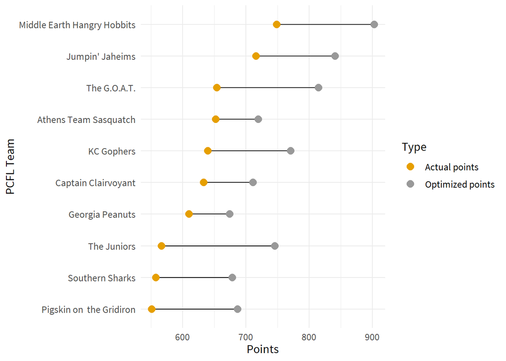

Both Crissy and Erin/Trav have definitely left some points on the bench.

### Best additions

There were 8 players added last week. Which was the **best new addition**?

| PCFL Team | Player | NFL Team | Position | Points |
| --- | --- | --- | --- | --- |
| KC Gophers | Mike Gesicki | MIA | TE | 21.90 |
| Georgia Peanuts | Kenneth Walker III | SEA | RB | 18.00 |
| Georgia Peanuts | Geno Smith | SEA | QB | 12.68 |
| Athens Team Sasquatch | Rams D/ST | LAR | DST | 10.00 |
| Athens Team Sasquatch | Harrison Butker | KCC | K | 10.00 |
| Jumpin’ Jaheims | Jakobi Meyers | NEP | WR | 8.00 |
| Athens Team Sasquatch | Taysom Hill | NOS | TE | 4.54 |
| KC Gophers | Derek Carr | OAK | QB | 0.00 |

I was VERY happy to pick up Kenneth Walker for my meager RB room. Mike Gesicki also had a nice week for Crissy.

### Best team performances

Here’s a list of the **top five scoring performances** so far this season.

| PCFL Team | Week | Score | Result |
| --- | --- | --- | --- |
| Middle Earth Hangry Hobbits | 1 | 148.06 | W |
| Georgia Peanuts | 2 | 147.22 | W |
| Southern Sharks | 4 | 143.96 | W |
| Jumpin’ Jaheims | 4 | 136.26 | W |
| Middle Earth Hangry Hobbits | 5 | 135.04 | W |

No new additions here this week (and maybe for a bit with the byes).

## Looking ahead

### League standings

| PCFL Team | Division | Points scored | Avg points | W | L | Team points |
| --- | --- | --- | --- | --- | --- | --- |
| Jumpin’ Jaheims | Grits | 716.18 | 119.36333 | 6 | 0 | 11 |
| Middle Earth Hangry Hobbits | Hot Dish | 748.73 | 124.78833 | 3 | 3 | 8 |
| The G.O.A.T. | Grits | 654.10 | 109.01667 | 3 | 3 | 8 |
| Athens Team Sasquatch | Grits | 652.74 | 108.79000 | 4 | 2 | 8 |
| KC Gophers | Hot Dish | 640.18 | 106.69667 | 4 | 2 | 7 |
| Georgia Peanuts | Hot Dish | 610.46 | 101.74333 | 3 | 3 | 5 |
| The Juniors | Hot Dish | 566.97 | 94.49500 | 3 | 3 | 4 |
| Captain Clairvoyant | Grits | 633.24 | 105.54000 | 2 | 4 | 4 |
| Pigskin on the Gridiron | Grits | 551.42 | 91.90333 | 1 | 5 | 3 |
| Southern Sharks | Hot Dish | 558.02 | 93.00333 | 1 | 5 | 2 |

### If the season ended today…

Current playoff teams (Team points): Evan, Robbie, Jacob, and Scott

### Next week’s matchups

| Team 1 | Team 2 |
| --- | --- |
| Athens Team Sasquatch (Avg. points: 108.79) | The Juniors (Avg. points: 94.5) |
| Captain Clairvoyant (Avg. points: 105.54) | KC Gophers (Avg. points: 106.7) |
| Georgia Peanuts (Avg. points: 101.74) | Pigskin on the Gridiron (Avg. points: 91.9) |
| Jumpin’ Jaheims (Avg. points: 119.36) | Southern Sharks (Avg. points: 93) |
| Middle Earth Hangry Hobbits (Avg. points: 124.79) | The G.O.A.T. (Avg. points: 109.02) |

Next week’s game of the week is Scott vs. Jacob, as two playoff contenders try to keep pace with the league. But it’s also worth keeping an eye on Evan vs. Sarah to see if the fantasy gods grant the upset and knock Evan from the ranks of the undefeated. Elsewhere, Richard tries to start a win streak against me, Robbie tries to get back in the win column vs. Erin/Trav, and Brian faces off against Crissy in two tightly matched teams.

Good luck, y’all!